# Agrupamento na base de dados de jogadores do FIFA 2019

Esta base de dados contém 89 atributos de 18.2K jogadores de futebol da edição 2019 do FIFA.

Link para a base de dados no Kaggle: https://www.kaggle.com/karangadiya/fifa19

Vamos usar as características técnicas de cada jogador, juntamente com a altura e peso para agrupá-los em um perfil técnico. Investigaremos as relações entre estes perfis e as posições originais dos jogadores.

[figure not shown]

## Importação das bibliotecas

```python
import numpy as np
import pandas as pd
import matplotlib.pyplot as plt
import matplotlib.cm as cm
from sklearn.preprocessing import MinMaxScaler
from sklearn.cluster import KMeans
from sklearn.decomposition import PCA
from sklearn.metrics import silhouette_samples, silhouette_score
from sklearn.ensemble import RandomForestClassifier
from collections import Counter
```

## Carregamento da base de dados

```python
df = pd.read_csv('data.csv')
```

```python
df.shape
```

```
(18207, 89)
```

```python
df.head()
```

|  | Unnamed: 0 | ID | Name | Age | Photo | Nationality | Flag | Overall | Potential | Club | Club Logo | Value | Wage | Special | Preferred Foot | International Reputation | Weak Foot | Skill Moves | Work Rate | Body Type | Real Face | Position | Jersey Number | Joined | Loaned From | Contract Valid Until | Height | Weight | LS | … |
| --- | --- | --- | --- | --- | --- | --- | --- | --- | --- | --- | --- | --- | --- | --- | --- | --- | --- | --- | --- | --- | --- | --- | --- | --- | --- | --- | --- | --- | --- | --- |
| 0 | 0 | 158023 | L. Messi | 31 | https://cdn.sofifa.org/players/4/19/158023.png | Argentina | https://cdn.sofifa.org/flags/52.png | 94 | 94 | FC Barcelona | https://cdn.sofifa.org/teams/2/light/241.png | €110.5M | €565K | 2202 | Left | 5.0 | 4.0 | 4.0 | Medium/ Medium | Messi | Yes | RF | 10.0 | Jul 1, 2004 | NaN | 2021 | 5'7 | 159lbs | 88+2 | … |
| 1 | 1 | 20801 | Cristiano Ronaldo | 33 | https://cdn.sofifa.org/players/4/19/20801.png | Portugal | https://cdn.sofifa.org/flags/38.png | 94 | 94 | Juventus | https://cdn.sofifa.org/teams/2/light/45.png | €77M | €405K | 2228 | Right | 5.0 | 4.0 | 5.0 | High/ Low | C. Ronaldo | Yes | ST | 7.0 | Jul 10, 2018 | NaN | 2022 | 6'2 | 183lbs | 91+3 | … |
| 2 | 2 | 190871 | Neymar Jr | 26 | https://cdn.sofifa.org/players/4/19/190871.png | Brazil | https://cdn.sofifa.org/flags/54.png | 92 | 93 | Paris Saint-Germain | https://cdn.sofifa.org/teams/2/light/73.png | €118.5M | €290K | 2143 | Right | 5.0 | 5.0 | 5.0 | High/ Medium | Neymar | Yes | LW | 10.0 | Aug 3, 2017 | NaN | 2022 | 5'9 | 150lbs | 84+3 | … |
| 3 | 3 | 193080 | De Gea | 27 | https://cdn.sofifa.org/players/4/19/193080.png | Spain | https://cdn.sofifa.org/flags/45.png | 91 | 93 | Manchester United | https://cdn.sofifa.org/teams/2/light/11.png | €72M | €260K | 1471 | Right | 4.0 | 3.0 | 1.0 | Medium/ Medium | Lean | Yes | GK | 1.0 | Jul 1, 2011 | NaN | 2020 | 6'4 | 168lbs | NaN | … |
| 4 | 4 | 192985 | K. De Bruyne | 27 | https://cdn.sofifa.org/players/4/19/192985.png | Belgium | https://cdn.sofifa.org/flags/7.png | 91 | 92 | Manchester City | https://cdn.sofifa.org/teams/2/light/10.png | €102M | €355K | 2281 | Right | 4.0 | 5.0 | 4.0 | High/ High | Normal | Yes | RCM | 7.0 | Aug 30, 2015 | NaN | 2023 | 5'11 | 154lbs | 82+3 | … |

5 rows × 89 columns

```python
for i, column in enumerate(df.columns):
  print(i, column)
```

```
0 Unnamed: 0
1 ID
2 Name
3 Age
4 Photo
5 Nationality
6 Flag
7 Overall
8 Potential
9 Club
10 Club Logo
11 Value
12 Wage
13 Special
14 Preferred Foot
```

[output cut: 74 more lines]

```python
columns = [21, 26, 27]
columns += range(54, 83)
```

```python
print(columns)
```

```
[21, 26, 27, 54, 55, 56, 57, 58, 59, 60, 61, 62, 63, 64, 65, 66, 67, 68, 69, 70, 71, 72, 73, 74, 75, 76, 77, 78, 79, 80, 81, 82]
```

```python
df = df.iloc[:, columns]
```

```python
df.head()
```

|  | Position | Height | Weight | Crossing | Finishing | HeadingAccuracy | ShortPassing | Volleys | Dribbling | Curve | FKAccuracy | LongPassing | BallControl | Acceleration | SprintSpeed | Agility | Reactions | Balance | ShotPower | Jumping | Stamina | Strength | LongShots | Aggression | Interceptions | Positioning | Vision | Penalties | Composure | … |
| --- | --- | --- | --- | --- | --- | --- | --- | --- | --- | --- | --- | --- | --- | --- | --- | --- | --- | --- | --- | --- | --- | --- | --- | --- | --- | --- | --- | --- | --- | --- |
| 0 | RF | 5'7 | 159lbs | 84.0 | 95.0 | 70.0 | 90.0 | 86.0 | 97.0 | 93.0 | 94.0 | 87.0 | 96.0 | 91.0 | 86.0 | 91.0 | 95.0 | 95.0 | 85.0 | 68.0 | 72.0 | 59.0 | 94.0 | 48.0 | 22.0 | 94.0 | 94.0 | 75.0 | 96.0 | … |
| 1 | ST | 6'2 | 183lbs | 84.0 | 94.0 | 89.0 | 81.0 | 87.0 | 88.0 | 81.0 | 76.0 | 77.0 | 94.0 | 89.0 | 91.0 | 87.0 | 96.0 | 70.0 | 95.0 | 95.0 | 88.0 | 79.0 | 93.0 | 63.0 | 29.0 | 95.0 | 82.0 | 85.0 | 95.0 | … |
| 2 | LW | 5'9 | 150lbs | 79.0 | 87.0 | 62.0 | 84.0 | 84.0 | 96.0 | 88.0 | 87.0 | 78.0 | 95.0 | 94.0 | 90.0 | 96.0 | 94.0 | 84.0 | 80.0 | 61.0 | 81.0 | 49.0 | 82.0 | 56.0 | 36.0 | 89.0 | 87.0 | 81.0 | 94.0 | … |
| 3 | GK | 6'4 | 168lbs | 17.0 | 13.0 | 21.0 | 50.0 | 13.0 | 18.0 | 21.0 | 19.0 | 51.0 | 42.0 | 57.0 | 58.0 | 60.0 | 90.0 | 43.0 | 31.0 | 67.0 | 43.0 | 64.0 | 12.0 | 38.0 | 30.0 | 12.0 | 68.0 | 40.0 | 68.0 | … |
| 4 | RCM | 5'11 | 154lbs | 93.0 | 82.0 | 55.0 | 92.0 | 82.0 | 86.0 | 85.0 | 83.0 | 91.0 | 91.0 | 78.0 | 76.0 | 79.0 | 91.0 | 77.0 | 91.0 | 63.0 | 90.0 | 75.0 | 91.0 | 76.0 | 61.0 | 87.0 | 94.0 | 79.0 | 88.0 | … |

```python
for i, column in enumerate(df.columns):
  print(i, column)
```

```
0 Position
1 Height
2 Weight
3 Crossing
4 Finishing
5 HeadingAccuracy
6 ShortPassing
7 Volleys
8 Dribbling
9 Curve
10 FKAccuracy
11 LongPassing
12 BallControl
13 Acceleration
14 SprintSpeed
```

[output cut: 17 more lines]

### Valores faltantes

```python
df.isna().sum(axis = 0)
```

```
Position           60
Height             48
Weight             48
Crossing           48
Finishing          48
HeadingAccuracy    48
ShortPassing       48
Volleys            48
Dribbling          48
Curve              48
FKAccuracy         48
LongPassing        48
BallControl        48
Acceleration       48
SprintSpeed        48
Agility            48
Reactions          48
Balance            48
ShotPower          48
Jumping            48
Stamina            48
Strength           48
LongShots          48
Aggression         48
Interceptions      48
Positioning        48
Vision             48
Penalties          48
Composure          48
Marking            48
StandingTackle     48
SlidingTackle      48
dtype: int64
```

```python
len(df)
```

```
18207
```

```python
len(df.dropna())
```

```
18147
```

```python
len(df) - len(df.dropna())
```

```
60
```

```python
(60 / 18207) * 100
```

```
0.32954358213873786
```

```python
df = df.dropna()
```

```python
df.shape
```

```
(18147, 32)
```

```python
df.isna().sum(axis = 0)
```

```
Position           0
Height             0
Weight             0
Crossing           0
Finishing          0
HeadingAccuracy    0
ShortPassing       0
Volleys            0
Dribbling          0
Curve              0
FKAccuracy         0
LongPassing        0
BallControl        0
Acceleration       0
SprintSpeed        0
Agility            0
Reactions          0
Balance            0
ShotPower          0
Jumping            0
Stamina            0
Strength           0
LongShots          0
Aggression         0
Interceptions      0
Positioning        0
Vision             0
Penalties          0
Composure          0
Marking            0
StandingTackle     0
SlidingTackle      0
dtype: int64
```

## Inspecionando as estatísticas

```python
def hist_boxplot(feature):
  fig, ax = plt.subplots(1, 2)
  ax[0].hist(feature)
  ax[1].boxplot(feature)
```

```python
df_describe = df.describe()
df_describe
```

|  | Crossing | Finishing | HeadingAccuracy | ShortPassing | Volleys | Dribbling | Curve | FKAccuracy | LongPassing | BallControl | Acceleration | SprintSpeed | Agility | Reactions | Balance | ShotPower | Jumping | Stamina | Strength | LongShots | Aggression | Interceptions | Positioning | Vision | Penalties | Composure | Marking | StandingTackle | SlidingTackle |
| --- | --- | --- | --- | --- | --- | --- | --- | --- | --- | --- | --- | --- | --- | --- | --- | --- | --- | --- | --- | --- | --- | --- | --- | --- | --- | --- | --- | --- | --- |
| count | 18147.000000 | 18147.000000 | 18147.000000 | 18147.000000 | 18147.000000 | 18147.000000 | 18147.000000 | 18147.000000 | 18147.000000 | 18147.000000 | 18147.000000 | 18147.000000 | 18147.000000 | 18147.000000 | 18147.000000 | 18147.000000 | 18147.000000 | 18147.000000 | 18147.000000 | 18147.000000 | 18147.000000 | 18147.000000 | 18147.000000 | 18147.000000 | 18147.000000 | 18147.000000 | 18147.000000 | 18147.000000 | 18147.000000 |
| mean | 49.738414 | 45.550229 | 52.300766 | 58.695432 | 42.912217 | 55.375158 | 47.176283 | 42.866038 | 52.721386 | 58.374828 | 64.612829 | 64.726236 | 63.501295 | 61.839147 | 63.964292 | 55.465201 | 65.091034 | 63.221579 | 65.318620 | 47.113187 | 55.876068 | 46.702761 | 49.962198 | 53.407781 | 48.546371 | 58.651127 | 47.286053 | 47.701879 | 45.666336 |
| std | 18.364255 | 19.527445 | 17.381753 | 14.696075 | 17.695900 | 18.912224 | 18.396009 | 17.480034 | 15.325211 | 16.685643 | 14.930320 | 14.651776 | 14.768956 | 9.011056 | 14.136073 | 17.235534 | 11.822327 | 15.896381 | 12.552479 | 19.263142 | 17.366534 | 20.697462 | 19.530469 | 14.146594 | 15.703113 | 11.437138 | 19.900450 | 21.663630 | 21.287961 |
| min | 5.000000 | 2.000000 | 4.000000 | 7.000000 | 4.000000 | 4.000000 | 6.000000 | 3.000000 | 9.000000 | 5.000000 | 12.000000 | 12.000000 | 14.000000 | 21.000000 | 16.000000 | 2.000000 | 15.000000 | 12.000000 | 17.000000 | 3.000000 | 11.000000 | 3.000000 | 2.000000 | 10.000000 | 5.000000 | 3.000000 | 3.000000 | 2.000000 | 3.000000 |
| 25% | 38.000000 | 30.000000 | 44.000000 | 54.000000 | 30.000000 | 49.000000 | 34.000000 | 31.000000 | 43.000000 | 54.000000 | 57.000000 | 57.000000 | 55.000000 | 56.000000 | 56.000000 | 45.000000 | 58.000000 | 56.000000 | 58.000000 | 33.000000 | 44.000000 | 26.000000 | 38.000000 | 44.000000 | 39.000000 | 51.000000 | 30.000000 | 27.000000 | 24.000000 |
| 50% | 54.000000 | 49.000000 | 56.000000 | 62.000000 | 44.000000 | 61.000000 | 48.000000 | 41.000000 | 56.000000 | 63.000000 | 67.000000 | 67.000000 | 66.000000 | 62.000000 | 66.000000 | 59.000000 | 66.000000 | 66.000000 | 67.000000 | 51.000000 | 59.000000 | 52.000000 | 55.000000 | 55.000000 | 49.000000 | 60.000000 | 53.000000 | 55.000000 | 52.000000 |
| 75% | 64.000000 | 62.000000 | 64.000000 | 68.000000 | 57.000000 | 68.000000 | 62.000000 | 57.000000 | 64.000000 | 69.000000 | 75.000000 | 75.000000 | 74.000000 | 68.000000 | 74.000000 | 68.000000 | 73.000000 | 74.000000 | 74.000000 | 62.000000 | 69.000000 | 64.000000 | 64.000000 | 64.000000 | 60.000000 | 67.000000 | 64.000000 | 66.000000 | 64.000000 |
| max | 93.000000 | 95.000000 | 94.000000 | 93.000000 | 90.000000 | 97.000000 | 94.000000 | 94.000000 | 93.000000 | 96.000000 | 97.000000 | 96.000000 | 96.000000 | 96.000000 | 96.000000 | 95.000000 | 95.000000 | 96.000000 | 97.000000 | 94.000000 | 95.000000 | 92.000000 | 95.000000 | 94.000000 | 92.000000 | 96.000000 | 94.000000 | 93.000000 | 91.000000 |

```python
df_describe.loc['min']
```

```
Crossing            5.0
Finishing           2.0
HeadingAccuracy     4.0
ShortPassing        7.0
Volleys             4.0
Dribbling           4.0
Curve               6.0
FKAccuracy          3.0
LongPassing         9.0
BallControl         5.0
Acceleration       12.0
SprintSpeed        12.0
Agility            14.0
Reactions          21.0
Balance            16.0
ShotPower           2.0
Jumping            15.0
Stamina            12.0
Strength           17.0
LongShots           3.0
Aggression         11.0
Interceptions       3.0
Positioning         2.0
Vision             10.0
Penalties           5.0
Composure           3.0
Marking             3.0
StandingTackle      2.0
SlidingTackle       3.0
Name: min, dtype: float64
```

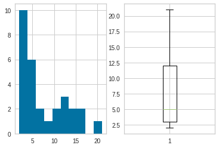

```python
hist_boxplot(df_describe.loc['min'])
```

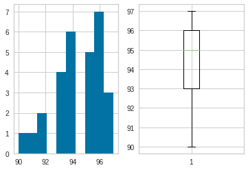

```python
hist_boxplot(df_describe.loc['max'])
```

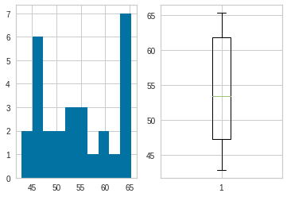

```python
hist_boxplot(df_describe.loc['mean'])
```

## Tratamento da altura do jogador

```python
df.dtypes
```

```
Position            object
Height              object
Weight              object
Crossing           float64
Finishing          float64
HeadingAccuracy    float64
ShortPassing       float64
Volleys            float64
Dribbling          float64
Curve              float64
FKAccuracy         float64
LongPassing        float64
BallControl        float64
Acceleration       float64
SprintSpeed        float64
Agility            float64
Reactions          float64
Balance            float64
ShotPower          float64
Jumping            float64
Stamina            float64
Strength           float64
LongShots          float64
Aggression         float64
Interceptions      float64
Positioning        float64
Vision             float64
Penalties          float64
Composure          float64
Marking            float64
StandingTackle     float64
SlidingTackle      float64
dtype: object
```

```python
df.dtypes[(x not in ['int64', 'float64'] for x in df.dtypes)]
```

```
Position    object
Height      object
Weight      object
dtype: object
```

```python
df['Height'].head()
```

```
0     5'7
1     6'2
2     5'9
3     6'4
4    5'11
Name: Height, dtype: object
```

```python
df['Height'] = df['Height'].str.split('\'')
df['Height']
```

```
0         [5, 7]
1         [6, 2]
2         [5, 9]
3         [6, 4]
4        [5, 11]
          ...
18202     [5, 9]
18203     [6, 3]
18204     [5, 8]
18205    [5, 10]
18206    [5, 10]
Name: Height, Length: 18147, dtype: object
```

```python
df['Height'] = [30.48 * int(elem[0]) + 2.54 * int(elem[1]) for elem in df['Height']]
df['Height']
```

```
0        170.18
1        187.96
2        175.26
3        193.04
4        180.34
          ...
18202    175.26
18203    190.50
18204    172.72
18205    177.80
18206    177.80
Name: Height, Length: 18147, dtype: float64
```

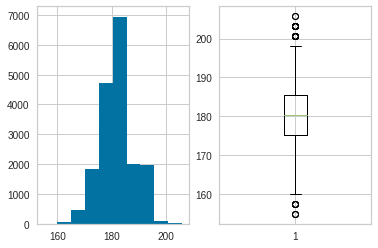

```python
hist_boxplot(df['Height'])
```

## Tratamento do peso do jogador

```python
df['Weight'].head()
```

```
0    159lbs
1    183lbs
2    150lbs
3    168lbs
4    154lbs
Name: Weight, dtype: object
```

```python
df['Weight'] = df['Weight'].str.split('l')
df['Weight']
```

```
0        [159, bs]
1        [183, bs]
2        [150, bs]
3        [168, bs]
4        [154, bs]
           ...
18202    [134, bs]
18203    [170, bs]
18204    [148, bs]
18205    [154, bs]
18206    [176, bs]
Name: Weight, Length: 18147, dtype: object
```

```python
df['Weight'] = [int(elem[0]) * 0.453 for elem in df['Weight']]
df['Weight']
```

```
0        72.027
1        82.899
2        67.950
3        76.104
4        69.762
          ...
18202    60.702
18203    77.010
18204    67.044
18205    69.762
18206    79.728
Name: Weight, Length: 18147, dtype: float64
```

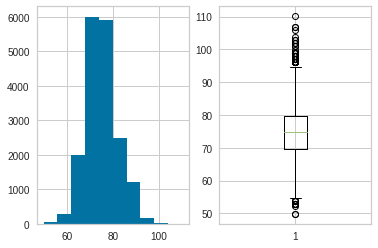

```python
hist_boxplot(df['Weight'])
```

## Preparação da base de dados para agrupamento

```python
position = np.array(df['Position'])
print(position)
```

```
['RF' 'ST' 'LW' ... 'ST' 'RW' 'CM']
```

```python
np.unique(position, return_counts=True)
```

```
(array(['CAM', 'CB', 'CDM', 'CF', 'CM', 'GK', 'LAM', 'LB', 'LCB', 'LCM',
        'LDM', 'LF', 'LM', 'LS', 'LW', 'LWB', 'RAM', 'RB', 'RCB', 'RCM',
        'RDM', 'RF', 'RM', 'RS', 'RW', 'RWB', 'ST'], dtype=object),
 array([ 958, 1778,  948,   74, 1394, 2025,   21, 1322,  648,  395,  243,
          15, 1095,  207,  381,   78,   21, 1291,  662,  391,  248,   16,
        1124,  203,  370,   87, 2152]))
```

```python
df = df.drop(['Position'], axis=1)
```

```python
df.head()
```

|  | Height | Weight | Crossing | Finishing | HeadingAccuracy | ShortPassing | Volleys | Dribbling | Curve | FKAccuracy | LongPassing | BallControl | Acceleration | SprintSpeed | Agility | Reactions | Balance | ShotPower | Jumping | Stamina | Strength | LongShots | Aggression | Interceptions | Positioning | Vision | Penalties | Composure | Marking | … |
| --- | --- | --- | --- | --- | --- | --- | --- | --- | --- | --- | --- | --- | --- | --- | --- | --- | --- | --- | --- | --- | --- | --- | --- | --- | --- | --- | --- | --- | --- | --- |
| 0 | 170.18 | 72.027 | 84.0 | 95.0 | 70.0 | 90.0 | 86.0 | 97.0 | 93.0 | 94.0 | 87.0 | 96.0 | 91.0 | 86.0 | 91.0 | 95.0 | 95.0 | 85.0 | 68.0 | 72.0 | 59.0 | 94.0 | 48.0 | 22.0 | 94.0 | 94.0 | 75.0 | 96.0 | 33.0 | … |
| 1 | 187.96 | 82.899 | 84.0 | 94.0 | 89.0 | 81.0 | 87.0 | 88.0 | 81.0 | 76.0 | 77.0 | 94.0 | 89.0 | 91.0 | 87.0 | 96.0 | 70.0 | 95.0 | 95.0 | 88.0 | 79.0 | 93.0 | 63.0 | 29.0 | 95.0 | 82.0 | 85.0 | 95.0 | 28.0 | … |
| 2 | 175.26 | 67.950 | 79.0 | 87.0 | 62.0 | 84.0 | 84.0 | 96.0 | 88.0 | 87.0 | 78.0 | 95.0 | 94.0 | 90.0 | 96.0 | 94.0 | 84.0 | 80.0 | 61.0 | 81.0 | 49.0 | 82.0 | 56.0 | 36.0 | 89.0 | 87.0 | 81.0 | 94.0 | 27.0 | … |
| 3 | 193.04 | 76.104 | 17.0 | 13.0 | 21.0 | 50.0 | 13.0 | 18.0 | 21.0 | 19.0 | 51.0 | 42.0 | 57.0 | 58.0 | 60.0 | 90.0 | 43.0 | 31.0 | 67.0 | 43.0 | 64.0 | 12.0 | 38.0 | 30.0 | 12.0 | 68.0 | 40.0 | 68.0 | 15.0 | … |
| 4 | 180.34 | 69.762 | 93.0 | 82.0 | 55.0 | 92.0 | 82.0 | 86.0 | 85.0 | 83.0 | 91.0 | 91.0 | 78.0 | 76.0 | 79.0 | 91.0 | 77.0 | 91.0 | 63.0 | 90.0 | 75.0 | 91.0 | 76.0 | 61.0 | 87.0 | 94.0 | 79.0 | 88.0 | 68.0 | … |

```python
scaler = MinMaxScaler()
df_train = scaler.fit_transform(df)
```

```python
type(df_train)
```

```
numpy.ndarray
```

```python
df_train[0]
```

```
array([0.3       , 0.36842105, 0.89772727, 1.        , 0.73333333,
       0.96511628, 0.95348837, 1.        , 0.98863636, 1.        ,
       0.92857143, 1.        , 0.92941176, 0.88095238, 0.93902439,
       0.98666667, 0.9875    , 0.89247312, 0.6625    , 0.71428571,
       0.525     , 1.        , 0.44047619, 0.21348315, 0.98924731,
       1.        , 0.8045977 , 1.        , 0.32967033, 0.28571429,
       0.26136364])
```

## Agrupamento com K-Means

### Escolha do número de clusters com WCSS

```python
wcss = []
K = range(1, 12)
for k in K:
  km = KMeans(n_clusters = k)
  km = km.fit(df_train)
  wcss.append(km.inertia_)
```

```python
wcss
```

```
[19914.28718803698,
 12555.880271124657,
 9381.810611713818,
 7595.510351331173,
 6934.252190142285,
 6442.550920018803,
 6114.1200662960555,
 5840.904784644471,
 5623.374326717121,
 5449.126676994249,
 5327.880978949296]
```

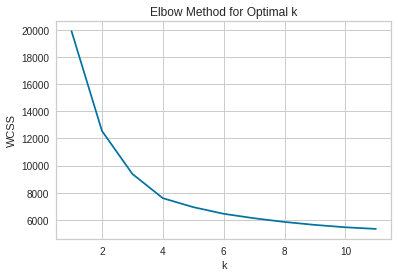

```python
plt.plot(K, wcss, 'bx-')
plt.xlabel('k')
plt.ylabel('WCSS')
plt.title('Elbow Method for Optimal k');
```

### Redução de dimensionalidade com PCA (Principal Component Analisys)

```python
pca = PCA(n_components=2)
df_pca = pca.fit_transform(df_train)
```

```python
df_pca
```

```
array([[-1.56786188, -1.06749087],
       [-1.48558143, -0.80876489],
       [-1.43389271, -0.95713023],
       ...,
       [ 0.70171909, -0.64105504],
       [ 0.61368167, -0.55466255],
       [ 0.52857009,  0.10029135]])
```

```python
df_train.shape
```

```
(18147, 31)
```

```python
df_pca.shape
```

```
(18147, 2)
```

```python
pca.explained_variance_ratio_
```

```
array([0.52943566, 0.20404527])
```

```python
exp_var = [round(i, 1) for i in pca.explained_variance_ratio_ * 100]
```

```python
exp_var
```

```
[52.9, 20.4]
```

### Escolha do número de clusters com o método da silhueta

- Leva em consideração a coesão e a separação
- Coesão: medida de distância de um ponto para todos os outros pontos do mesmo grupo
- Separação: medida de distância de um ponto com os pontos dos outros clusters
- O coeficiente está no intervalo de [-1, 1]
- O valor -1 indica que o cluster está ruim (registros em grupos "errados")
- O valor 0 indica "indiferença" (em cima da linha de decisão, um cluster ao lado do outro)
- O valor 1 indica que os cluster estão bem distantes

Código baseado na documentação: https://scikit-learn.org/stable/auto_examples/cluster/plot_kmeans_silhouette_analysis.html

```
For n_clusters =  2  Average score:  0.4703559214248003
For n_clusters =  3  Average score:  0.2853119307185486
For n_clusters =  4  Average score:  0.27054139480884387
For n_clusters =  5  Average score:  0.24277984096086125
For n_clusters =  6  Average score:  0.2173940307436049
For n_clusters =  7  Average score:  0.20890123641990385
For n_clusters =  8  Average score:  0.20272419316326296
For n_clusters =  9  Average score:  0.1891313715604252
For n_clusters =  10  Average score:  0.18359029329361964
For n_clusters =  11  Average score:  0.17703691646748654
```

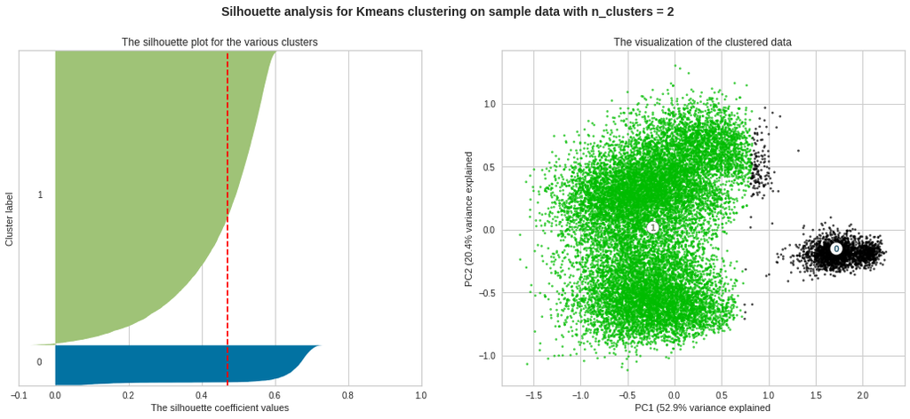

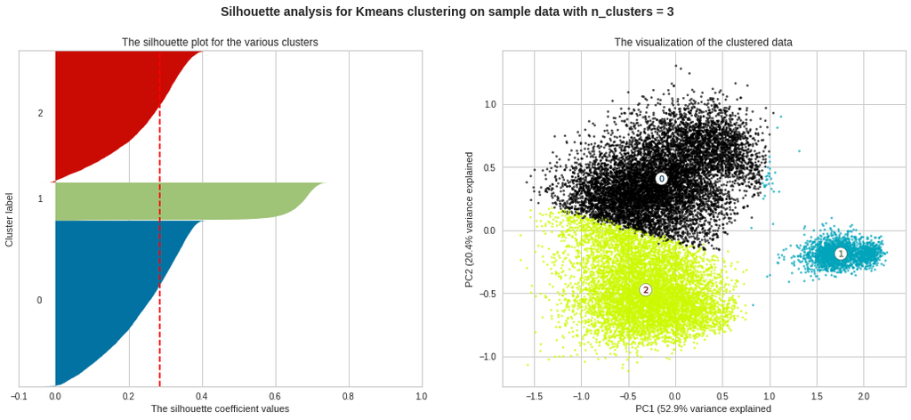

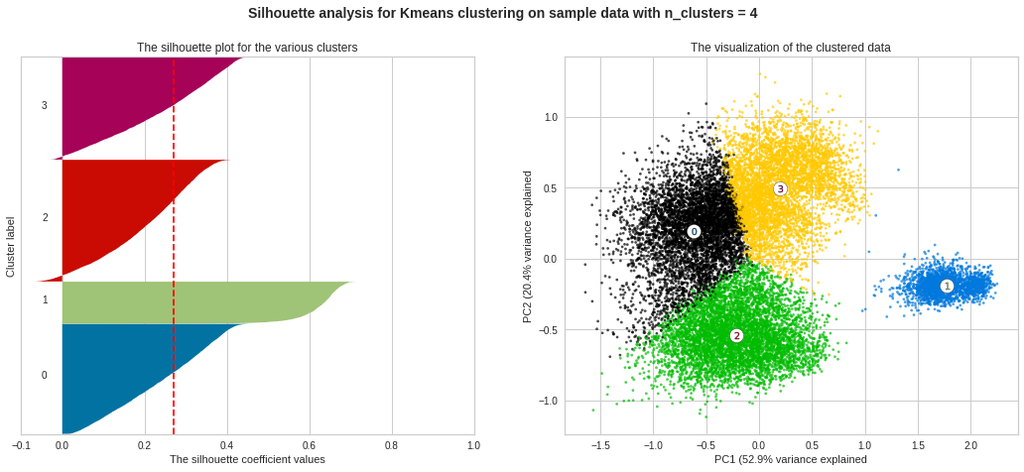

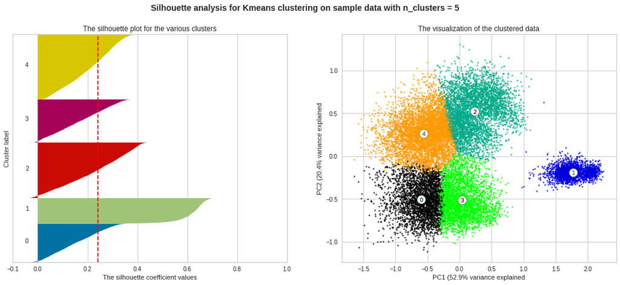

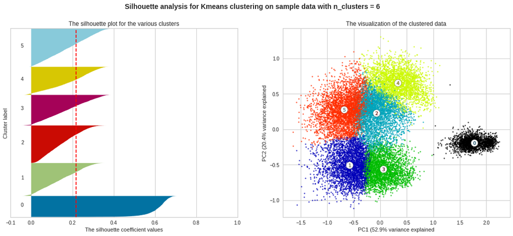

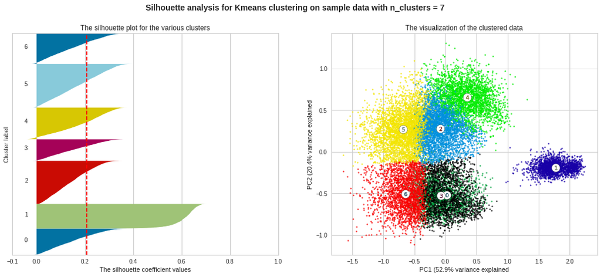

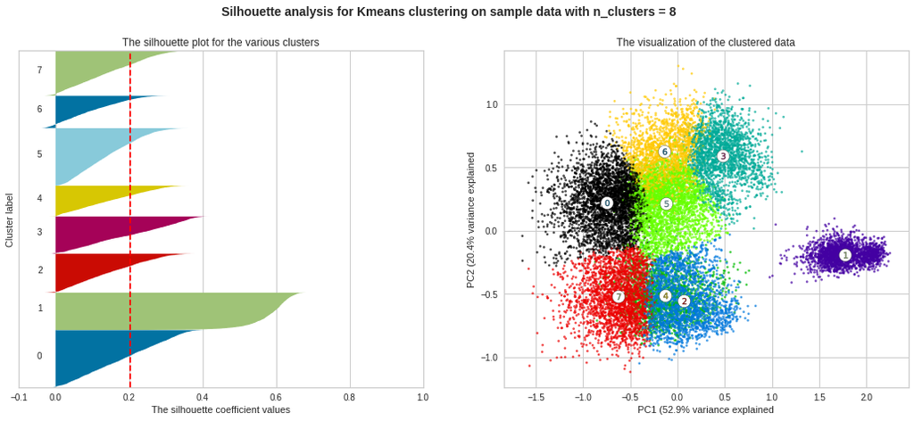

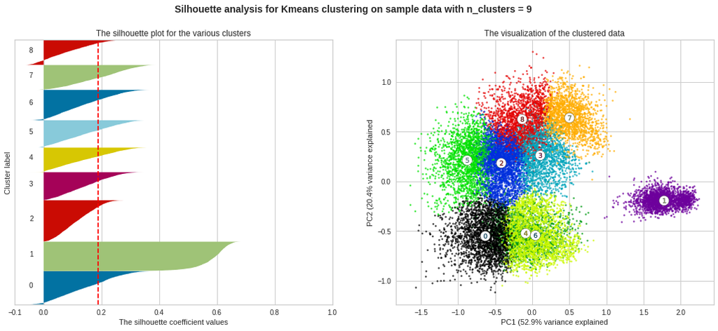

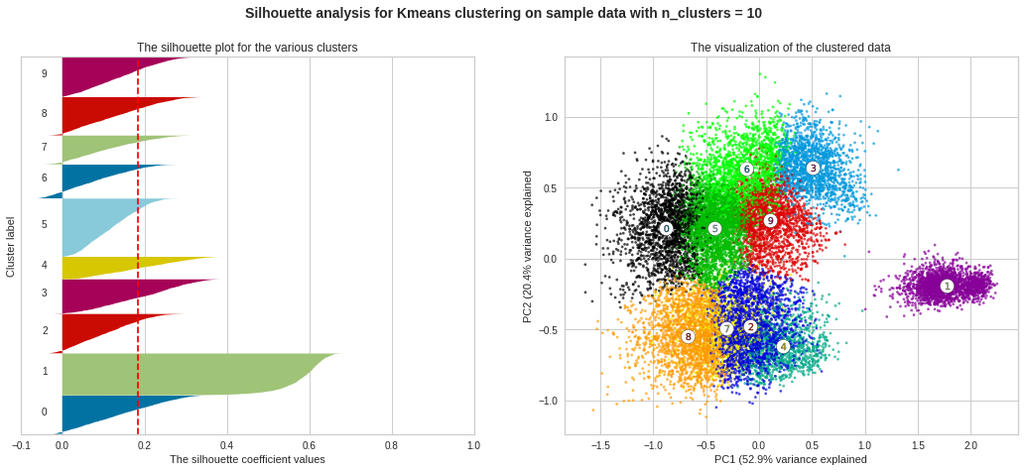

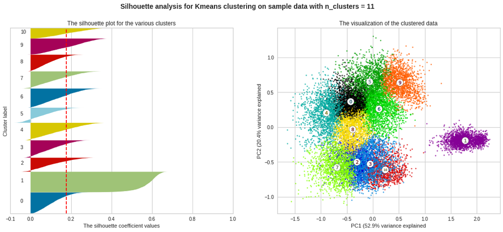

```python
range_n_clusters = range(2, 12)
for n_clusters in range_n_clusters:
  fig, (ax1, ax2) = plt.subplots(1, 2)
  fig.set_size_inches(18, 7)

  ax1.set_xlim([-0.1, 1])
  ax1.set_ylim([0, len(df_train) + (n_clusters + 1) * 10])

  clusterer = KMeans(n_clusters=n_clusters, random_state=10)
  cluster_labels = clusterer.fit_predict(df_train)
  #print(cluster_labels)
  #print(np.unique(cluster_labels))

  silhouette_avg = silhouette_score(df_train, cluster_labels)
  print("For n_clusters = ", n_clusters, " Average score: ", silhouette_avg)

  sample_silhouette_values = silhouette_samples(df_train, cluster_labels)
  #print(sample_silhouette_values)
  #print(len(sample_silhouette_values))

  y_lower = 10
  for i in range(n_clusters):
    ith_cluster_silhouette_values = sample_silhouette_values[cluster_labels == i]
    ith_cluster_silhouette_values.sort()
    #print(ith_cluster_silhouette_values.shape)

    size_cluster_i = ith_cluster_silhouette_values.shape[0]

    y_upper = y_lower + size_cluster_i
    #print(y_upper)

    ax1.fill_betweenx(np.arange(y_lower, y_upper), ith_cluster_silhouette_values)

    ax1.text(-0.05, y_lower + 0.5 * size_cluster_i, str(i))

    y_lower = y_upper + 10

  ax1.set_title("The silhouette plot for the various clusters")
  ax1.set_xlabel("The silhouette coefficient values")
  ax1.set_ylabel("Cluster label")

  ax1.axvline(x = silhouette_avg, color = "red", linestyle = "--")

  ax1.set_yticks([])
  ax1.set_xticks([-0.1, 0, 0.2, 0.4, 0.6, 0.8, 1])

  colors = cm.nipy_spectral(cluster_labels.astype(float) / n_clusters)
  ax2.scatter(df_pca[:, 0], df_pca[:, 1], marker='.', s=30, lw=0, alpha=0.7, c=colors, edgecolor='k')

  centers = clusterer.cluster_centers_
  centers = pca.transform(centers)
  ax2.scatter(centers[:, 0], centers[:,1], marker='o', c='white', alpha=1, s=200, edgecolor='k')

  for i, c in enumerate(centers):
    ax2.scatter(c[0], c[1], marker='$%d$' % i, s=50, edgecolor='k')

  ax2.set_title("The visualization of the clustered data")
  ax2.set_xlabel('PC1 (' + str(exp_var[0]) + '% variance explained')
  ax2.set_ylabel('PC2 (' + str(exp_var[1]) + '% variance explained')

  plt.suptitle(("Silhouette analysis for Kmeans clustering on sample data with n_clusters = %d" % n_clusters),
               fontsize=14, fontweight='bold')
```

### Aplicação do k-means

```python
km = KMeans(n_clusters=4, n_init=100, random_state=0)
km.fit(df_train)
```

```
KMeans(algorithm='auto', copy_x=True, init='k-means++', max_iter=300,
       n_clusters=4, n_init=100, n_jobs=None, precompute_distances='auto',
       random_state=0, tol=0.0001, verbose=0)
```

```python
print(km.cluster_centers_)
```

```
[[0.47013853 0.38293013 0.5576947  0.64974042 0.55672615 0.63006471
  0.59752368 0.66477984 0.55792792 0.50148757 0.50811364 0.66493571
  0.71487037 0.72121845 0.69870311 0.52860612 0.67339234 0.66919714
  0.6048123  0.61194385 0.55008338 0.6054462  0.44945108 0.29457726
  0.65413198 0.57697069 0.62462919 0.61157546 0.32979437 0.30457434
  0.27978412]
 [0.65466206 0.53151997 0.10523837 0.10798309 0.11573754 0.23573043
  0.09783045 0.10612113 0.09896511 0.12593179 0.20004933 0.16441772
  0.30959691 0.31790471 0.3193654  0.50540372 0.33857918 0.22087305
  0.53352861 0.21978293 0.54510977 0.10621988 0.18329927 0.1580905
  0.09979789 0.32106444 0.17276537 0.45280116 0.13459505 0.13372222
  0.12617729]
 [0.56041038 0.44628469 0.44585185 0.31361683 0.61720199 0.578172
  0.31988557 0.47179015 0.34797507 0.34161212 0.49725312 0.5396597
  0.57416782 0.59151412 0.52113478 0.50161336 0.54102293 0.4827029
  0.65366124 0.62808096 0.66392828 0.3432104  0.62415821 0.6502162
  0.39670303 0.39151603 0.40769104 0.55578701 0.63781803 0.68147564
  0.67069   ]
 [0.47911166 0.39676615 0.66678312 0.55092621 0.59999162 0.7303716
  0.55238699 0.67473422 0.62214516 0.5779656  0.6784412  0.7054087
  0.67350833 0.67690988 0.68495782 0.6172589  0.67277442 0.69268038
  0.65925594 0.73933691 0.62972699 0.62910119 0.67760369 0.68575564
  0.63368662 0.64259893 0.57603507 0.6794839  0.6525259  0.69299166
  0.67386235]]
```

```python
print(km.labels_)
```

```
[0 0 0 ... 0 0 2]
```

```python
len(km.labels_)
```

```
18147
```

## Relacionamento entre os grupos e as posições

```python
len(position)
```

```
18147
```

```python
position[0]
```

```
'RF'
```

```python
groups = km.labels_
compar = []
for i in range(0, len(position)):
  elem = tuple((position[i], groups[i]))
  compar.append(elem)
```

```python
compar[0:4]
```

```
[('RF', 0), ('ST', 0), ('LW', 0), ('GK', 1)]
```

```python
count = Counter(compar)
count
```

```
Counter({('CAM', 0): 660,
         ('CAM', 2): 18,
         ('CAM', 3): 280,
         ('CB', 0): 1,
         ('CB', 1): 1,
         ('CB', 2): 1621,
         ('CB', 3): 155,
         ('CDM', 0): 4,
         ('CDM', 2): 384,
         ('CDM', 3): 560,
         ('CF', 0): 68,
         ('CF', 3): 6,
         ('CM', 0): 224,
         ('CM', 2): 325,
         ('CM', 3): 845,
         ('GK', 1): 2024,
         ('GK', 2): 1,
         ('LAM', 0): 18,
         ('LAM', 3): 3,
         ('LB', 0): 7,
         ('LB', 2): 596,
         ('LB', 3): 719,
         ('LCB', 0): 1,
         ('LCB', 2): 533,
         ('LCB', 3): 114,
         ('LCM', 0): 56,
         ('LCM', 2): 31,
         ('LCM', 3): 308,
         ('LDM', 0): 6,
         ('LDM', 2): 48,
         ('LDM', 3): 189,
         ('LF', 0): 11,
         ('LF', 3): 4,
         ('LM', 0): 805,
         ('LM', 2): 33,
         ('LM', 3): 257,
         ('LS', 0): 192,
         ('LS', 3): 15,
         ('LW', 0): 330,
         ('LW', 2): 2,
```

[output cut: 22 more lines]

```
         ('RM', 2): 36,
         ('RM', 3): 285,
         ('RS', 0): 191,
         ('RS', 2): 1,
         ('RS', 3): 11,
         ('RW', 0): 324,
         ('RW', 2): 1,
         ('RW', 3): 45,
         ('RWB', 0): 2,
         ('RWB', 2): 37,
         ('RWB', 3): 48,
         ('ST', 0): 2068,
         ('ST', 1): 1,
         ('ST', 2): 10,
         ('ST', 3): 73})
```

```python
compar = pd.DataFrame({'Position': [i[0] for i in list(count.keys())],
                       'Group': [i[1] for i in list(count.keys())],
                       'N': list(count.values())})
```

```python
compar.head()
```

|  | Position | Group | N |
| --- | --- | --- | --- |
| 0 | RF | 0 | 12 |
| 1 | ST | 0 | 2068 |
| 2 | LW | 0 | 330 |
| 3 | GK | 1 | 2024 |
| 4 | RCM | 3 | 323 |

```python
compar.shape
```

```
(77, 3)
```

```python
compar = compar.sort_values(['Position', 'Group'])
compar.head()
```

|  | Position | Group | N |
| --- | --- | --- | --- |
| 30 | CAM | 0 | 660 |
| 64 | CAM | 2 | 18 |
| 12 | CAM | 3 | 280 |
| 66 | CB | 0 | 1 |
| 74 | CB | 1 | 1 |

```python
compar_perc = pd.DataFrame()
pos = compar['Position'].unique()
pos
```

```
array(['CAM', 'CB', 'CDM', 'CF', 'CM', 'GK', 'LAM', 'LB', 'LCB', 'LCM',
       'LDM', 'LF', 'LM', 'LS', 'LW', 'LWB', 'RAM', 'RB', 'RCB', 'RCM',
       'RDM', 'RF', 'RM', 'RS', 'RW', 'RWB', 'ST'], dtype=object)
```

```python
compar[compar['Position'] == 'CAM']
```

|  | Position | Group | N |
| --- | --- | --- | --- |
| 30 | CAM | 0 | 660 |
| 64 | CAM | 2 | 18 |
| 12 | CAM | 3 | 280 |

```python
sum(compar[compar['Position'] == 'CAM']['N'])
```

```
958
```

```python
for p in pos:
  compar_p = compar[compar['Position'] == p]
  sum_N = sum(compar_p['N'])
  compar_p['N'] = compar_p['N'] / sum_N
  compar_perc = compar_perc.append(compar_p)
compar_perc = compar_perc.sort_values(['Group', 'N', 'Position'])
```

```python
compar_perc.head()
```

|  | Position | Group | N |
| --- | --- | --- | --- |
| 66 | CB | 0 | 0.000562 |
| 61 | RCB | 0 | 0.001511 |
| 71 | LCB | 0 | 0.001543 |
| 65 | RB | 0 | 0.003098 |
| 67 | CDM | 0 | 0.004219 |

```python
compar_perc.tail()
```

|  | Position | Group | N |
| --- | --- | --- | --- |
| 27 | CM | 3 | 0.606169 |
| 10 | LDM | 3 | 0.777778 |
| 24 | RDM | 3 | 0.778226 |
| 8 | LCM | 3 | 0.779747 |
| 4 | RCM | 3 | 0.826087 |

```python
compar_perc_barplot = pd.DataFrame({'Position': sum([[elem] * 4 for elem in np.unique(position)], []),
                                    'Group': sum([['0', '1', '2', '3'] * len(np.unique(position))], []),
                                    'N': [0] * 4 * len(np.unique(position))})
```

```python
compar_perc_barplot.head(8)
```

|  | Position | Group | N |
| --- | --- | --- | --- |
| 0 | CAM | 0 | 0 |
| 1 | CAM | 1 | 0 |
| 2 | CAM | 2 | 0 |
| 3 | CAM | 3 | 0 |
| 4 | CB | 0 | 0 |
| 5 | CB | 1 | 0 |
| 6 | CB | 2 | 0 |
| 7 | CB | 3 | 0 |

```python
compar_perc_barplot.tail(8)
```

|  | Position | Group | N |
| --- | --- | --- | --- |
| 100 | RWB | 0 | 0 |
| 101 | RWB | 1 | 0 |
| 102 | RWB | 2 | 0 |
| 103 | RWB | 3 | 0 |
| 104 | ST | 0 | 0 |
| 105 | ST | 1 | 0 |
| 106 | ST | 2 | 0 |
| 107 | ST | 3 | 0 |

```python
len(compar_perc_barplot)
```

```
108
```

```python
for row in range(0, len(compar_perc_barplot)):
  pos = compar_perc_barplot.iloc[row, 0]
  gro = int(compar_perc_barplot.iloc[row, 1])
  reg = compar_perc.loc[(compar_perc['Position'] == pos) & (compar_perc['Group'] == gro), :]
  if len(reg) > 0:
    compar_perc_barplot.iloc[row, 2] = reg['N'].values
```

```python
compar_perc_barplot.head(8)
```

|  | Position | Group | N |
| --- | --- | --- | --- |
| 0 | CAM | 0 | 0.688935 |
| 1 | CAM | 1 | 0.000000 |
| 2 | CAM | 2 | 0.018789 |
| 3 | CAM | 3 | 0.292276 |
| 4 | CB | 0 | 0.000562 |
| 5 | CB | 1 | 0.000562 |
| 6 | CB | 2 | 0.911699 |
| 7 | CB | 3 | 0.087177 |

```python
compar_perc_barplot.tail(8)
```

|  | Position | Group | N |
| --- | --- | --- | --- |
| 100 | RWB | 0 | 0.022989 |
| 101 | RWB | 1 | 0.000000 |
| 102 | RWB | 2 | 0.425287 |
| 103 | RWB | 3 | 0.551724 |
| 104 | ST | 0 | 0.960967 |
| 105 | ST | 1 | 0.000465 |
| 106 | ST | 2 | 0.004647 |
| 107 | ST | 3 | 0.033922 |

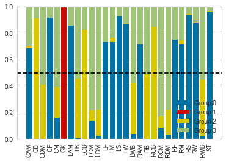

```python
p0 = plt.bar(compar_perc_barplot['Position'][compar_perc_barplot['Group'] == '0'],
             compar_perc_barplot['N'][compar_perc_barplot['Group'] == '0'], color = 'b')
p1 = plt.bar(compar_perc_barplot['Position'][compar_perc_barplot['Group'] == '1'],
             compar_perc_barplot['N'][compar_perc_barplot['Group'] == '1'], color = 'r',
             bottom = np.array(compar_perc_barplot['N'][compar_perc_barplot['Group'] == '0']))
p2 = plt.bar(compar_perc_barplot['Position'][compar_perc_barplot['Group'] == '2'],
             compar_perc_barplot['N'][compar_perc_barplot['Group'] == '2'], color = 'y',
             bottom = np.array(compar_perc_barplot['N'][compar_perc_barplot['Group'] == '0']) +
                      np.array(compar_perc_barplot['N'][compar_perc_barplot['Group'] == '1']))
p3 = plt.bar(compar_perc_barplot['Position'][compar_perc_barplot['Group'] == '3'],
             compar_perc_barplot['N'][compar_perc_barplot['Group'] == '3'], color = 'g',
             bottom = np.array(compar_perc_barplot['N'][compar_perc_barplot['Group'] == '0']) +
                      np.array(compar_perc_barplot['N'][compar_perc_barplot['Group'] == '1']) +
                      np.array(compar_perc_barplot['N'][compar_perc_barplot['Group'] == '2']))
plt.xticks(rotation = 90)
plt.axhline(0.5, color = 'black', linestyle='--')
plt.legend((p0[0], p1[0], p2[0], p3[0]), ('Group 0', 'Group 1', 'Group 2', 'Group 3'))
```

```python
counter1 = Counter(compar_perc[compar_perc['N'] >= 0.5]['Group'])
counter1
```

```
Counter({0: 13, 1: 1, 2: 3, 3: 10})
```

```python
counter1 = dict(sorted(counter1.items(), key = lambda x: x[0]))
counter1
```

```
{0: 13, 1: 1, 2: 3, 3: 10}
```

```python
x = [str(elem) for elem in list(counter1.keys())]
x
```

```
['0', '1', '2', '3']
```

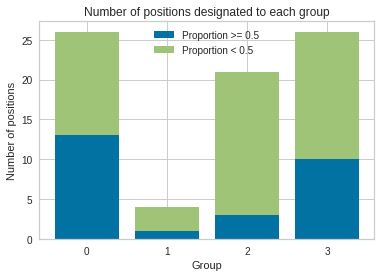

```python
p1 = plt.bar(x, counter1.values())
counter2 = Counter(compar_perc[compar_perc['N'] < 0.5]['Group'])
counter2 = dict(sorted(counter2.items(), key = lambda x: x[0]))
x = [str(elem) for elem in list(counter2.keys())]

p2 = plt.bar(x, counter2.values(), bottom=list(counter1.values()))
plt.title('Number of positions designated to each group')
plt.xlabel('Group')
plt.ylabel('Number of positions')
plt.legend((p1[0], p2[0]), ('Proportion >= 0.5', 'Proportion < 0.5'))
```

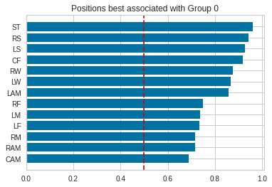

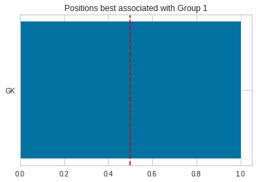

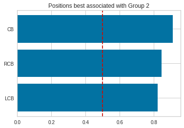

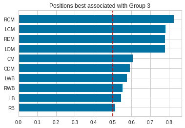

```python
for i in range(4):
  g = compar_perc[(compar_perc['Group'] == i) & (compar_perc['N'] >= 0.5)][['Position', 'N']]
  g = g.sort_values(by = 'N')
  plt.barh(g['Position'], g['N'])
  plt.axvline(0.5, color = 'r', linestyle = '--')
  plt.title('Positions best associated with Group ' + str(i))
  plt.show()
```

## Seleção de atributos com Random Forest

```python
rfc = RandomForestClassifier()
rfc.fit(df_train, groups)
```

```
RandomForestClassifier(bootstrap=True, ccp_alpha=0.0, class_weight=None,
                       criterion='gini', max_depth=None, max_features='auto',
                       max_leaf_nodes=None, max_samples=None,
                       min_impurity_decrease=0.0, min_impurity_split=None,
                       min_samples_leaf=1, min_samples_split=2,
                       min_weight_fraction_leaf=0.0, n_estimators=100,
                       n_jobs=None, oob_score=False, random_state=None,
                       verbose=0, warm_start=False)
```

```python
importances = rfc.feature_importances_
importances
```

```
array([0.00249525, 0.00280243, 0.01834158, 0.05767173, 0.03156101,
       0.01198247, 0.05709767, 0.05694645, 0.04691265, 0.0194245 ,
       0.01460811, 0.03675483, 0.00480042, 0.00441138, 0.00727025,
       0.00436204, 0.00643506, 0.01663602, 0.00297558, 0.01520333,
       0.00354532, 0.0795406 , 0.01276665, 0.10369219, 0.04487777,
       0.0340842 , 0.01874285, 0.00602689, 0.06053756, 0.12560227,
       0.09189095])
```

```python
features = df.columns
features
```

```
Index(['Height', 'Weight', 'Crossing', 'Finishing', 'HeadingAccuracy',
       'ShortPassing', 'Volleys', 'Dribbling', 'Curve', 'FKAccuracy',
       'LongPassing', 'BallControl', 'Acceleration', 'SprintSpeed', 'Agility',
       'Reactions', 'Balance', 'ShotPower', 'Jumping', 'Stamina', 'Strength',
       'LongShots', 'Aggression', 'Interceptions', 'Positioning', 'Vision',
       'Penalties', 'Composure', 'Marking', 'StandingTackle', 'SlidingTackle'],
      dtype='object')
```

```python
df_imp = pd.DataFrame({'Features': features, 'Importance': importances})
df_imp.head()
```

|  | Features | Importance |
| --- | --- | --- |
| 0 | Height | 0.002495 |
| 1 | Weight | 0.002802 |
| 2 | Crossing | 0.018342 |
| 3 | Finishing | 0.057672 |
| 4 | HeadingAccuracy | 0.031561 |

```python
df_imp = df_imp.sort_values(by = 'Importance', ascending = False)
df_imp.head()
```

|  | Features | Importance |
| --- | --- | --- |
| 29 | StandingTackle | 0.125602 |
| 23 | Interceptions | 0.103692 |
| 30 | SlidingTackle | 0.091891 |
| 21 | LongShots | 0.079541 |
| 28 | Marking | 0.060538 |

```python
df_imp.tail()
```

|  | Features | Importance |
| --- | --- | --- |
| 15 | Reactions | 0.004362 |
| 20 | Strength | 0.003545 |
| 18 | Jumping | 0.002976 |
| 1 | Weight | 0.002802 |
| 0 | Height | 0.002495 |

```python
df_imp['Sum Importance'] = df_imp['Importance'].cumsum()
df_imp = df_imp.sort_values(by = 'Importance')
df_imp.head()
```

|  | Features | Importance | Sum Importance |
| --- | --- | --- | --- |
| 0 | Height | 0.002495 | 1.000000 |
| 1 | Weight | 0.002802 | 0.997505 |
| 18 | Jumping | 0.002976 | 0.994702 |
| 20 | Strength | 0.003545 | 0.991727 |
| 15 | Reactions | 0.004362 | 0.988181 |

```python
df_imp.tail()
```

|  | Features | Importance | Sum Importance |
| --- | --- | --- | --- |
| 28 | Marking | 0.060538 | 0.461264 |
| 21 | LongShots | 0.079541 | 0.400726 |
| 30 | SlidingTackle | 0.091891 | 0.321185 |
| 23 | Interceptions | 0.103692 | 0.229294 |
| 29 | StandingTackle | 0.125602 | 0.125602 |

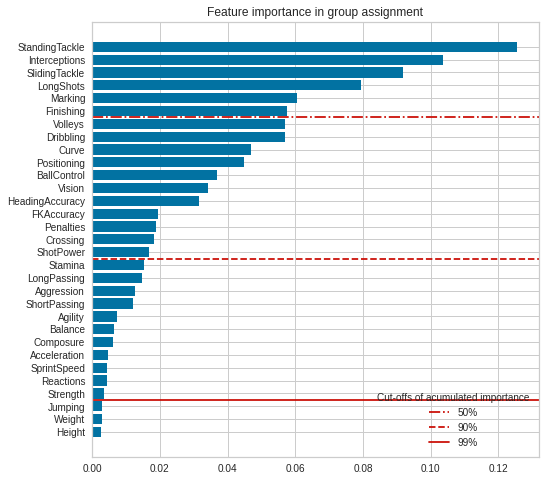

```python
plt.figure(figsize=(8,8))
plt.barh(df_imp['Features'], df_imp['Importance'])
l1 = plt.axhline(len(df_imp) - (len(df_imp['Features'][df_imp['Sum Importance'] < 0.50]) + 1.5), linestyle='-.', color = 'r')
l2 = plt.axhline(len(df_imp) - (len(df_imp['Features'][df_imp['Sum Importance'] < 0.90]) + 1.5), linestyle='--', color = 'r')
l3 = plt.axhline(len(df_imp) - (len(df_imp['Features'][df_imp['Sum Importance'] < 0.99]) + 1.5), linestyle='-', color = 'r')
plt.legend(title = 'Cut-offs of acumulated importance', handles=(l1, l2, l3), labels = ('50%', '90%', '99%'))
plt.title('Feature importance in group assignment')
```

## Conclusões

Este exercício sugere que os jogadores de futebol do jogo FIFA podem ser separados em 4 perfis técnicos e também determina quais são os recursos técnicos mais importantes para atribuir um jogador ao seu grupo. Uma análise desse tipo seria importante, por exemplo, para verificar se um jogador está atribuído à sua posição mais eficiente no campo e também para sugerir quais recursos técnicos devem ser aprimorados (por treinamento físico) para garantir que um jogador seja um bom representante do perfil técnico desejado.

## Classificação com Random Forest

### Divisão da base de dados

```python
from sklearn.model_selection import train_test_split
from sklearn.metrics import accuracy_score, confusion_matrix
```

```python
X_train, X_test, y_train, y_test = train_test_split(df_train, groups, test_size = 0.2)
```

```python
X_train.shape
```

```
(14517, 31)
```

```python
y_train.shape
```

```
(14517,)
```

```python
X_test.shape
```

```
(3630, 31)
```

```python
y_test.shape
```

```
(3630,)
```

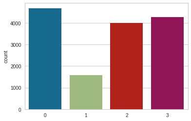

```python
import seaborn as sns
sns.countplot(y_train)
```

### Treinamento e avaliação do algoritmo

```python
rfc = RandomForestClassifier()
rfc.fit(X_train, y_train)
```

```
RandomForestClassifier(bootstrap=True, ccp_alpha=0.0, class_weight=None,
                       criterion='gini', max_depth=None, max_features='auto',
                       max_leaf_nodes=None, max_samples=None,
                       min_impurity_decrease=0.0, min_impurity_split=None,
                       min_samples_leaf=1, min_samples_split=2,
                       min_weight_fraction_leaf=0.0, n_estimators=100,
                       n_jobs=None, oob_score=False, random_state=None,
                       verbose=0, warm_start=False)
```

```python
predictions = rfc.predict(X_test)
predictions
```

```
array([3, 0, 1, ..., 0, 1, 1], dtype=int32)
```

```python
y_test
```

```
array([3, 0, 1, ..., 0, 1, 1], dtype=int32)
```

```python
accuracy_score(predictions, y_test)
```

```
0.9707988980716253
```

```python
cm = confusion_matrix(predictions, y_test)
cm
```

```
array([[1144,    0,    6,   23],
       [   0,  443,    0,    0],
       [   2,    1,  942,   24],
       [  21,    0,   29,  995]])
```

```python
!pip install yellowbrick --upgrade
```

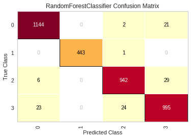

```python
from yellowbrick.classifier import ConfusionMatrix
confusion_matrix = ConfusionMatrix(rfc)
confusion_matrix.fit(X_train, y_train)
confusion_matrix.score(X_test, y_test)
confusion_matrix.show();
```

### Previsão de um jogador

```python
new = X_test[0]
new
```

```
array([0.3       , 0.39849624, 0.70454545, 0.51612903, 0.41111111,
       0.68604651, 0.44186047, 0.64516129, 0.67045455, 0.63736264,
       0.66666667, 0.68131868, 0.76470588, 0.73809524, 0.7804878 ,
       0.66666667, 0.8375    , 0.61290323, 0.6125    , 0.73809524,
       0.55      , 0.46153846, 0.61904762, 0.7752809 , 0.56989247,
       0.51190476, 0.42528736, 0.65591398, 0.61538462, 0.71428571,
       0.75      ])
```

```python
new.shape
```

```
(31,)
```

```python
new = new.reshape(1, -1)
new.shape
```

```
(1, 31)
```

```python
rfc.predict(new)
```

```
array([3], dtype=int32)
```

```python
rfc.predict_proba(new)
```

```
array([[0., 0., 0., 1.]])
```